# tidymodels: An end-to-end snapshot

[figure not shown]

https://www.tidymodels.org/

`tidymodels::`, as a successor of `caret::`, is a meta-package which has a modular approach meaning that specific, smaller packages are designed to work hand in hand.

Thus,

**tidymodels** is to **modeling** what the **tidyverse** is to **data wrangling**.

Herein, I will walk through a machine learning example from start to end and explain how to use the appropriate tidymodels packages at each place.

# Set Up

Loading the **tidymodels** package loads a bunch of packages for modeling and also a few others from the tidyverse like **ggplot2** and **dplyr**.

```r
library(tidymodels)
library(tidyverse)
ggplot2::theme_set(theme_light())
library(tidylog, warn.conflicts = FALSE) # load this last!

library(skimr)
library(patchwork)
library(gt)
library(ggrepel)
```

## Data Set: Diamonds

[figure not shown]

With **ggplot2** comes the diamonds data set, which has information on the size and quality of diamonds.

```r
data(diamonds, package="ggplot2")

str(diamonds)
```

```
-->  tibble [53,940 x 10] (S3: tbl_df/tbl/data.frame)
-->   $ carat  : num [1:53940] 0.23 0.21 0.23 0.29 0.31 0.24 0.24 0.26 0.22 0.23 ...
-->   $ cut    : Ord.factor w/ 5 levels "Fair"<"Good"<..: 5 4 2 4 2 3 3 3 1 3 ...
-->   $ color  : Ord.factor w/ 7 levels "D"<"E"<"F"<"G"<..: 2 2 2 6 7 7 6 5 2 5 ...
-->   $ clarity: Ord.factor w/ 8 levels "I1"<"SI2"<"SI1"<..: 2 3 5 4 2 6 7 3 4 5 ...
-->   $ depth  : num [1:53940] 61.5 59.8 56.9 62.4 63.3 62.8 62.3 61.9 65.1 59.4 ...
-->   $ table  : num [1:53940] 55 61 65 58 58 57 57 55 61 61 ...
-->   $ price  : int [1:53940] 326 326 327 334 335 336 336 337 337 338 ...
-->   $ x      : num [1:53940] 3.95 3.89 4.05 4.2 4.34 3.94 3.95 4.07 3.87 4 ...
-->   $ y      : num [1:53940] 3.98 3.84 4.07 4.23 4.35 3.96 3.98 4.11 3.78 4.05 ...
-->   $ z      : num [1:53940] 2.43 2.31 2.31 2.63 2.75 2.48 2.47 2.53 2.49 2.39 ...
```

A data frame with 53940 rows and 10 variables:

- `price`: price in US dollars ($326–$18,823)
- `carat`: weight of the diamond (0.2–5.01)
- `cut`: quality of the cut (Fair, Good, Very Good, Premium, Ideal)
- `color`: diamond colour, from D (best) to J (worst)
- `clarity`: a measurement of how clear the diamond is (I1 (worst), SI2, SI1, VS2, VS1, VVS2, VVS1, IF (best))
- `x`: length in mm (0–10.74)

[figure not shown]

- `y`: width in mm (0–58.9)
- `z`: depth in mm (0–31.8)
- `depth`: total depth percentage = z / mean(x, y) = 2 * z / (x + y) (43–79)
- `table`: width of top of diamond relative to widest point (43–95)

```r
DT::datatable(sample_n(diamonds, 3000),
              caption="ggplot2::diamond dataset (3,000 samples)")
```

```
-->      ---->  sample_n: removed 50,940 rows (94%), 3,000 rows remaining
```

|  | carat | cut | color | clarity | depth | table | price | x | y | z |
| --- | --- | --- | --- | --- | --- | --- | --- | --- | --- | --- |
| 1 | 1.3 | Premium | I | VS2 | 60.1 | 58 | 6442 | 7.1 | 7.14 | 4.28 |
| 2 | 2.34 | Good | J | VS2 | 63.9 | 62 | 12961 | 8.4 | 8.34 | 5.35 |
| 3 | 0.25 | Ideal | H | VS1 | 61.7 | 57 | 431 | 4.04 | 4.07 | 2.5 |
| 4 | 1.51 | Premium | E | SI1 | 61.5 | 61 | 11565 | 7.41 | 7.31 | 4.53 |
| 5 | 1.2 | Premium | J | VS2 | 60.3 | 59 | 4715 | 6.9 | 6.94 | 4.17 |
| 6 | 0.8 | Ideal | F | SI1 | 61 | 56 | 3137 | 5.98 | 6.05 | 3.67 |
| 7 | 0.24 | Ideal | F | VS1 | 61.3 | 56 | 419 | 4 | 4.03 | 2.46 |
| 8 | 0.62 | Ideal | I | VVS1 | 61.1 | 55 | 2207 | 5.52 | 5.57 | 3.39 |
| 9 | 0.7 | Ideal | E | VVS2 | 62.4 | 54 | 3585 | 5.66 | 5.71 | 3.55 |
| 10 | 2.13 | Ideal | I | SI2 | 62.6 | 56 | 12356 | 8.21 | 8.14 | 5.12 |

[output cut: 2990 more lines]

```r
skimr::skim(diamonds)
```

Data summary

| Name | diamonds |
| --- | --- |
| Number of rows | 53940 |
| Number of columns | 10 |
| _______________________ |  |
| Column type frequency: |  |
| factor | 3 |
| numeric | 7 |
| ________________________ |  |
| Group variables | None |

**Variable type: factor**

| skim_variable | n_missing | complete_rate | ordered | n_unique | top_counts |
| --- | --- | --- | --- | --- | --- |
| cut | 0 | 1 | TRUE | 5 | Ide: 21551, Pre: 13791, Ver: 12082, Goo: 4906 |
| color | 0 | 1 | TRUE | 7 | G: 11292, E: 9797, F: 9542, H: 8304 |
| clarity | 0 | 1 | TRUE | 8 | SI1: 13065, VS2: 12258, SI2: 9194, VS1: 8171 |

**Variable type: numeric**

| skim_variable | n_missing | complete_rate | mean | sd | p0 | p25 | p50 | p75 | p100 | hist |
| --- | --- | --- | --- | --- | --- | --- | --- | --- | --- | --- |
| carat | 0 | 1 | 0.80 | 0.47 | 0.2 | 0.40 | 0.70 | 1.04 | 5.01 | ▇▂▁▁▁ |
| depth | 0 | 1 | 61.75 | 1.43 | 43.0 | 61.00 | 61.80 | 62.50 | 79.00 | ▁▁▇▁▁ |
| table | 0 | 1 | 57.46 | 2.23 | 43.0 | 56.00 | 57.00 | 59.00 | 95.00 | ▁▇▁▁▁ |
| price | 0 | 1 | 3932.80 | 3989.44 | 326.0 | 950.00 | 2401.00 | 5324.25 | 18823.00 | ▇▂▁▁▁ |
| x | 0 | 1 | 5.73 | 1.12 | 0.0 | 4.71 | 5.70 | 6.54 | 10.74 | ▁▁▇▃▁ |
| y | 0 | 1 | 5.73 | 1.14 | 0.0 | 4.72 | 5.71 | 6.54 | 58.90 | ▇▁▁▁▁ |
| z | 0 | 1 | 3.54 | 0.71 | 0.0 | 2.91 | 3.53 | 4.04 | 31.80 | ▇▁▁▁▁ |

Herein, we’ll use these features to **predict** the **price** of a diamond.

Using the `tidymodels` modules in downstream fashions.

[figure not shown]

```r
imsi <-  diamonds %>%
    sample_n(2000) %>%
    mutate_if(is.factor, as.numeric) %>%
    select(price, everything())
```

```
-->      ---->  sample_n: removed 51,940 rows (96%), 2,000 rows remaining
-->      ---->  mutate_if: converted 'cut' from ordered factor to double (0 new NA)
-->      ---->             converted 'color' from ordered factor to double (0 new NA)
-->      ---->             converted 'clarity' from ordered factor to double (0 new NA)
-->      ---->  select: columns reordered (price, carat, cut, color, clarity, …)
```

```r
cor(imsi)
```

```
-->            price   carat     cut   color clarity   depth   table       x      y       z
-->  price    1.0000  0.9201 -0.0291  0.1584 -0.1515 -0.0185  0.1306  0.8836  0.885  0.8813
-->  carat    0.9201  1.0000 -0.1093  0.2822 -0.3675  0.0238  0.1783  0.9766  0.975  0.9781
-->  cut     -0.0291 -0.1093  1.0000 -0.0042  0.1715 -0.2131 -0.4515 -0.1014 -0.102 -0.1271
-->  color    0.1584  0.2822 -0.0042  1.0000  0.0361  0.0776  0.0299  0.2637  0.260  0.2706
-->  clarity -0.1515 -0.3675  0.1715  0.0361  1.0000 -0.0728 -0.1336 -0.3871 -0.380 -0.3921
-->  depth   -0.0185  0.0238 -0.2131  0.0776 -0.0728  1.0000 -0.3164 -0.0345 -0.039  0.0861
-->  table    0.1306  0.1783 -0.4515  0.0299 -0.1336 -0.3164  1.0000  0.1922  0.187  0.1519
-->   [ getOption("max.print") 에 도달했습니다 -- 3 행들을 생략합니다 ]
```

```r
class(cor(imsi))
```

```
-->  [1] "matrix" "array"
```

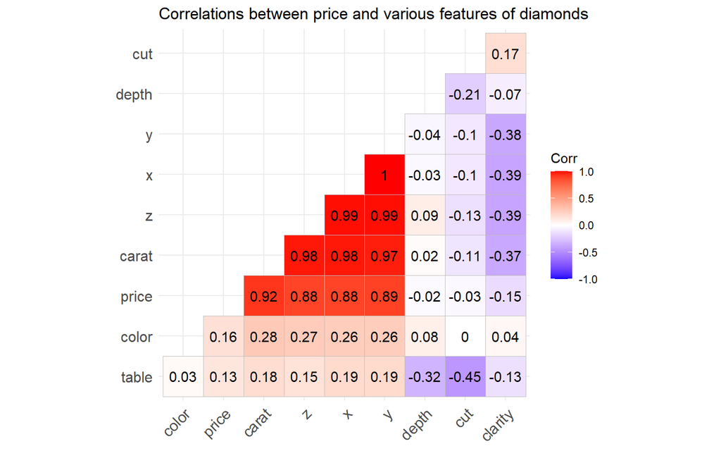

```r
ggcorrplot::ggcorrplot(cor(imsi),
                       hc.order=T,
                       type="lower",
                       lab=T) +
 ggtitle("Correlations between price and various features of diamonds")
```

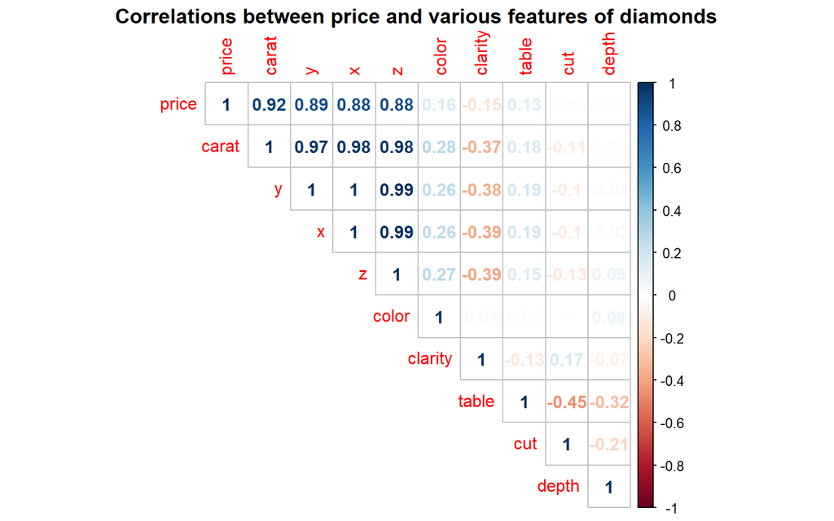

```r
cor(imsi) %>%
    {.[order(abs(.[, 1]), decreasing = TRUE),
       order(abs(.[, 1]), decreasing = TRUE)]} %>%
    corrplot::corrplot(method = "number",
             type = "upper",
             mar = c(0, 0, 1.5, 0),
             title = "Correlations between price and various features of diamonds")
```

# 1 Allocating Testing and Training Data: `rsample::`

First of all, we want to extract a data set for testing the predictions in the end. We’ll only use a small proportion for training (only to speed things up a little). Furthermore, the training data set will be prepared for 3-fold cross-validation (using three here to speed things up). All this is accomplished using the **rsample** package:

```r
set.seed(1243)

dia_split <- initial_split(diamonds, prop = .1, strata = price)

dia_train <- training(dia_split)
dia_test  <- testing(dia_split)

dim(dia_train)
```

```
-->  [1] 5395   10
```

```r
dim(dia_test)
```

```
-->  [1] 48545    10
```

```r
dia_vfold <- vfold_cv(dia_train,
                      v = 3,
                      repeats = 1,
                      strata = price)
dia_vfold %>%
  mutate(df_ana = map(splits, analysis),
         df_ass = map(splits, assessment))
```

```
-->      ---->  mutate: new variable 'df_ana' (list) with 3 unique values and 0% NA
-->      ---->          new variable 'df_ass' (list) with 3 unique values and 0% NA
```

```
-->  #  3-fold cross-validation using stratification
-->  # A tibble: 3 x 4
-->    splits              id    df_ana                df_ass
-->    <list>              <chr> <list>                <list>
-->  1 <split [3.6K/1.8K]> Fold1 <tibble [3,596 x 10]> <tibble [1,799 x 10]>
-->  2 <split [3.6K/1.8K]> Fold2 <tibble [3,596 x 10]> <tibble [1,799 x 10]>
-->  3 <split [3.6K/1.8K]> Fold3 <tibble [3,598 x 10]> <tibble [1,797 x 10]>
```

# 2 Pre-Processing and Feature Engineering: `recipes::`

The **recipes** package can be used to prepare a data set (for modeling) using different `step_*()` functions.

For example, the plot below indicates that there may be a nonlinear relationship between price and carat, and I want to address that using higher-order terms.

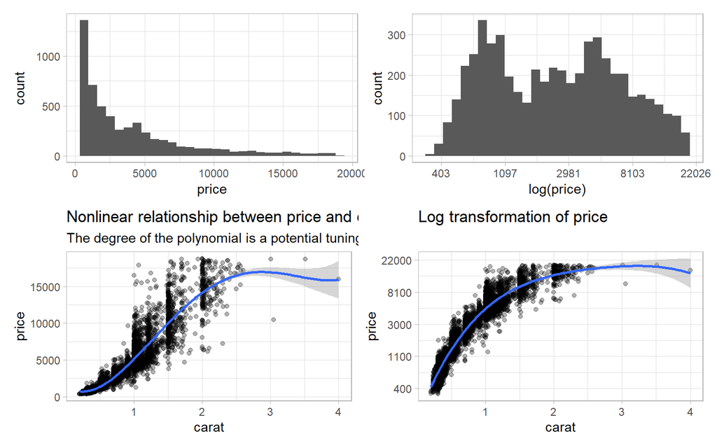

```r
p1 <-
 ggplot(dia_train, aes(x=price)) +
 geom_histogram()

p2 <-
 ggplot(dia_train, aes(x=price)) +
 geom_histogram() +
 scale_x_continuous(trans=log_trans()) +
 xlab("log(price)")

p3 <-
 ggplot(data = dia_train, mapping=aes(x=carat, y=price)) +
 geom_point(alpha=0.3) +
 scale_y_continuous(labels = function(x) round(x, -2)) +
 geom_smooth(method = "lm", formula = "y ~ poly(x, 4)") +
 labs(title = "Nonlinear relationship between price and carat of diamonds",
      subtitle = "The degree of the polynomial is a potential tuning parameter")
p4 <-
 ggplot(data = dia_train, mapping=aes(x=carat, y=price)) +
 geom_point(alpha=0.3) +
 scale_y_continuous(trans = log_trans(),
                    labels = function(x) round(x, -2)) +
 geom_smooth(method = "lm", formula = "y ~ poly(x, 4)") +
 labs(title = "Log transformation of price")

(p1 + p2) / (p3 + p4)
```

The `recipe()` takes a formula and a data set, and then the different steps are added using the appropriate `recipe::step_*()` functions.

The **recipes** package comes with a ton of useful step functions (see, e.g., `vignette("Simple_Example", package = "recipes")`).

Herein, I want to

1. log transform price (`step_log()`),
2. center and scale all numeric predictors (`step_normalize()`), and
3. the categorical predictors should be dummy coded (`step_dummy()`). Furthermore,
4. a quadratic effect of carat is added using `step_poly()`.

```r
dia_rec <-
    recipe(price ~ ., data = dia_train) %>%
    step_log(all_outcomes()) %>%
    step_normalize(all_predictors(), -all_nominal()) %>%
    step_dummy(all_nominal()) %>%
    step_poly(carat, degree = 2)
```

`recipe::prep()` *trains* a data recipe.

For a recipe with at least one preprocessing operation, estimate the required parameters from a training set that can be later applied to other data sets.

```r
prep(dia_rec)
```

```
-->  Data Recipe
-->
-->  Inputs:
-->
-->        role #variables
-->     outcome          1
-->   predictor          9
-->
-->  Training data contained 5395 data points and no missing data.
-->
-->  Operations:
-->
-->  Log transformation on price [trained]
-->  Centering and scaling for carat, depth, table, x, y, z [trained]
-->  Dummy variables from cut, color, clarity [trained]
-->  Orthogonal polynomials on carat [trained]
```

For a recipe with at least one preprocessing operation that has been trained by `prep()`, `recipe::bake()` apply a trrained data recipe.

```r
# Note the linear and quadratic term for carat and the dummies for e.g. color
dia_baked <- bake(prep(dia_rec),
                   new_data=NULL)
dim(dia_baked)
```

```
-->  [1] 5395   25
```

```r
names(dia_baked)
```

```
-->   [1] "depth"        "table"        "x"            "y"            "z"            "price"        "cut_1"        "cut_2"        "cut_3"        "cut_4"        "color_1"      "color_2"      "color_3"      "color_4"      "color_5"      "color_6"      "clarity_1"    "clarity_2"    "clarity_3"    "clar…
```

```r
skimr::skim(dia_baked)
```

Data summary

| Name | dia_baked |
| --- | --- |
| Number of rows | 5395 |
| Number of columns | 25 |
| _______________________ |  |
| Column type frequency: |  |
| numeric | 25 |
| ________________________ |  |
| Group variables | None |

**Variable type: numeric**

| skim_variable | n_missing | complete_rate | mean | sd | p0 | p25 | p50 | p75 | p100 | hist |
| --- | --- | --- | --- | --- | --- | --- | --- | --- | --- | --- |
| depth | 0 | 1 | 0.00 | 1.00 | -6.07 | -0.47 | 0.09 | 0.51 | 12.05 | ▁▇▁▁▁ |
| table | 0 | 1 | 0.00 | 1.00 | -2.90 | -0.66 | -0.21 | 0.69 | 6.97 | ▂▇▂▁▁ |
| x | 0 | 1 | 0.00 | 1.00 | -5.07 | -0.92 | -0.02 | 0.72 | 3.79 | ▁▁▇▅▁ |
| y | 0 | 1 | 0.00 | 1.00 | -5.11 | -0.92 | -0.01 | 0.73 | 3.76 | ▁▁▇▆▁ |
| z | 0 | 1 | 0.00 | 1.00 | -5.06 | -0.91 | -0.01 | 0.71 | 3.97 | ▁▁▇▅▁ |
| price | 0 | 1 | 7.79 | 1.02 | 5.83 | 6.86 | 7.78 | 8.58 | 9.84 | ▅▇▇▇▅ |
| cut_1 | 0 | 1 | 0.29 | 0.35 | -0.63 | 0.00 | 0.32 | 0.63 | 0.63 | ▁▂▅▆▇ |
| cut_2 | 0 | 1 | 0.01 | 0.46 | -0.53 | -0.27 | -0.27 | 0.53 | 0.53 | ▅▇▁▁▇ |
| cut_3 | 0 | 1 | 0.00 | 0.43 | -0.63 | -0.63 | 0.00 | 0.32 | 0.63 | ▆▁▅▇▂ |
| cut_4 | 0 | 1 | 0.04 | 0.45 | -0.48 | -0.48 | 0.12 | 0.12 | 0.72 | ▇▁▇▁▅ |
| color_1 | 0 | 1 | -0.08 | 0.32 | -0.57 | -0.38 | 0.00 | 0.19 | 0.57 | ▇▅▆▃▅ |
| color_2 | 0 | 1 | -0.10 | 0.35 | -0.44 | -0.33 | -0.33 | 0.00 | 0.55 | ▇▁▅▁▃ |
| color_3 | 0 | 1 | 0.02 | 0.36 | -0.41 | -0.41 | 0.00 | 0.41 | 0.41 | ▇▁▅▁▇ |
| color_4 | 0 | 1 | 0.02 | 0.39 | -0.56 | -0.56 | 0.08 | 0.24 | 0.48 | ▅▁▁▇▃ |
| color_5 | 0 | 1 | 0.01 | 0.39 | -0.55 | -0.44 | 0.00 | 0.44 | 0.55 | ▇▃▇▁▇ |
| color_6 | 0 | 1 | -0.04 | 0.43 | -0.66 | -0.20 | 0.03 | 0.49 | 0.49 | ▆▇▅▁▇ |
| clarity_1 | 0 | 1 | -0.07 | 0.26 | -0.54 | -0.23 | -0.08 | 0.08 | 0.54 | ▃▅▇▂▂ |
| clarity_2 | 0 | 1 | -0.18 | 0.24 | -0.39 | -0.39 | -0.23 | 0.08 | 0.54 | ▇▁▃▁▁ |
| clarity_3 | 0 | 1 | 0.12 | 0.30 | -0.43 | -0.18 | 0.18 | 0.43 | 0.43 | ▃▂▁▅▇ |
| clarity_4 | 0 | 1 | -0.02 | 0.35 | -0.52 | -0.12 | -0.12 | 0.36 | 0.36 | ▅▁▆▁▇ |
| clarity_5 | 0 | 1 | -0.03 | 0.38 | -0.49 | -0.36 | -0.32 | 0.36 | 0.49 | ▇▁▁▁▆ |
| clarity_6 | 0 | 1 | -0.01 | 0.40 | -0.31 | -0.31 | -0.31 | 0.55 | 0.55 | ▇▁▁▁▅ |
| clarity_7 | 0 | 1 | 0.01 | 0.42 | -0.60 | -0.36 | 0.02 | 0.36 | 0.60 | ▃▇▁▅▇ |
| carat_poly_1 | 0 | 1 | 0.00 | 0.01 | -0.02 | -0.01 | 0.00 | 0.01 | 0.09 | ▇▃▁▁▁ |
| carat_poly_2 | 0 | 1 | 0.00 | 0.01 | -0.01 | -0.01 | 0.00 | 0.01 | 0.36 | ▇▁▁▁▁ |

# 3 Defining and Fitting Models: `parsnip::`

The **parsnip** package has wrappers around many popular machine learning algorithms, and you can fit them using a unified interface.

- For a list of models available via **parsnip**, see https://tidymodels.github.io/parsnip/articles/articles/Models.html.] This is extremely helpful, since you have to remember only one rather then dozens of interfaces.

The models are separated into two modes/categories, namely, **regression** and **classification** (`parsnip::set_mode()`).

The model is defined using a function specific to each algorithm (e.g., `linear_reg()`, `rand_forest()`).

Finally, the backend/engine/implementation is selected using `parsnip::set_engine()`.

Herein, I will start with a basic linear regression model as implemented in `stats::lm()`.

```r
lm_model <-
    linear_reg() %>%
    set_mode("regression") %>%
    set_engine("lm")
```

Furthermore, take the example of a random forest model.

- This could be fit using packages **ranger::** or **randomForest::**.
- Both have different interfaces (e.g., argument `ntree` vs. `num.trees`), and **parsnip** removes the hassle of remembering both interfaces.

More general arguments pertaining to the algorithm are specified in the algorithm function (e.g., `rand_forest()`).

Arguments specific to the engine are specified in `set_engine()`.

```r
rand_forest(mtry = 3, trees = 500, min_n = 5) %>%
    set_mode("regression") %>%
    set_engine("ranger", importance = "impurity_corrected")
```

```
-->  Random Forest Model Specification (regression)
-->
-->  Main Arguments:
-->    mtry = 3
-->    trees = 500
-->    min_n = 5
-->
-->  Engine-Specific Arguments:
-->    importance = impurity_corrected
-->
-->  Computational engine: ranger
```

Finally, we can `fit()` the model.

```r
lm_fit1 <- fit(lm_model,
               price ~ .,
               data=dia_baked)
lm_fit1
```

```
-->  parsnip model object
-->
-->  Fit time:  20ms
-->
-->  Call:
-->  stats::lm(formula = price ~ ., data = data)
-->
-->  Coefficients:
-->   (Intercept)         depth         table             x             y             z         cut_1         cut_2         cut_3         cut_4       color_1       color_2       color_3       color_4       color_5       color_6     clarity_1     clarity_2     clarity_3     clarity_4     clarity_5   …
-->       7.71197       0.01087       0.00589       0.25115       0.05442       0.05420       0.10670      -0.02636       0.02421      -0.00619      -0.45583      -0.08411      -0.00481       0.00972      -0.00559      -0.00973       0.86096      -0.24270       0.13223      -0.05290       0.02900   …
```

```r
broom::tidy(lm_fit1)
```

```
-->  # A tibble: 25 x 5
-->     term        estimate std.error statistic  p.value
-->     <chr>          <dbl>     <dbl>     <dbl>    <dbl>
-->   1 (Intercept)  7.71      0.00431   1790.   0.
-->   2 depth        0.0109    0.00467      2.33 2.00e- 2
-->   3 table        0.00589   0.00283      2.08 3.74e- 2
-->   4 x            0.251     0.0418       6.00 2.04e- 9
-->   5 y            0.0544    0.0480       1.13 2.57e- 1
-->   6 z            0.0542    0.0316       1.72 8.61e- 2
-->   7 cut_1        0.107     0.00997     10.7  1.88e-26
-->   8 cut_2       -0.0264    0.00805     -3.28 1.06e- 3
-->   9 cut_3        0.0242    0.00687      3.53 4.26e- 4
-->  10 cut_4       -0.00619   0.00541     -1.15 2.52e- 1
-->  # ... with 15 more rows
```

```r
broom::tidy(lm_fit1) %>%
 gt::gt(tidy(lm_fit1))
```

| term | estimate | std.error | statistic | p.value |
| --- | --- | --- | --- | --- |
| (Intercept) | 7.71197 | 0.00431 | 1789.633 | 0.00e+00 |
| depth | 0.01087 | 0.00467 | 2.327 | 2.00e-02 |
| table | 0.00589 | 0.00283 | 2.081 | 3.74e-02 |
| x | 0.25115 | 0.04183 | 6.005 | 2.04e-09 |
| y | 0.05442 | 0.04797 | 1.134 | 2.57e-01 |
| z | 0.05420 | 0.03157 | 1.716 | 8.61e-02 |
| cut_1 | 0.10670 | 0.00997 | 10.700 | 1.88e-26 |
| cut_2 | -0.02636 | 0.00805 | -3.275 | 1.06e-03 |
| cut_3 | 0.02421 | 0.00687 | 3.526 | 4.26e-04 |
| cut_4 | -0.00619 | 0.00541 | -1.145 | 2.52e-01 |
| color_1 | -0.45583 | 0.00738 | -61.793 | 0.00e+00 |
| color_2 | -0.08411 | 0.00665 | -12.654 | 3.50e-36 |
| color_3 | -0.00481 | 0.00631 | -0.762 | 4.46e-01 |
| color_4 | 0.00972 | 0.00584 | 1.666 | 9.58e-02 |
| color_5 | -0.00559 | 0.00559 | -1.001 | 3.17e-01 |
| color_6 | -0.00973 | 0.00500 | -1.945 | 5.19e-02 |
| clarity_1 | 0.86096 | 0.01345 | 63.995 | 0.00e+00 |
| clarity_2 | -0.24270 | 0.01267 | -19.155 | 3.63e-79 |
| clarity_3 | 0.13223 | 0.01075 | 12.303 | 2.51e-34 |
| clarity_4 | -0.05290 | 0.00839 | -6.303 | 3.15e-10 |
| clarity_5 | 0.02900 | 0.00676 | 4.290 | 1.82e-05 |
| clarity_6 | 0.00240 | 0.00589 | 0.408 | 6.83e-01 |
| clarity_7 | 0.02224 | 0.00526 | 4.225 | 2.42e-05 |
| carat_poly_1 | 51.66397 | 1.09864 | 47.025 | 0.00e+00 |
| carat_poly_2 | -17.50832 | 0.25861 | -67.701 | 0.00e+00 |

You can use `fit()` with a formula (e.g., `price ~ .`) or by specifying `x` and `y`. In both cases, I recommend keeping only the variables you need when preparing the data set, since this will prevent forgetting the new variable `d` when using `y ~ a + b + c`. Unnecessary variables can easily be dropped in the recipe using `step_rm()`.

# 4 Summarizing Fitted Models: `broom::`

Many models have implemented `summary()` or `coef()` methods. However, the output of these is usually not in a tidy format, and the **broom::** package has the aim to resolve this issue.

`broom::glance()` gives us information about the whole model. Here, R squared is pretty high and the RMSE equals 0.154.

```r
broom::glance(lm_fit1$fit) %>% gt()
```

| r.squared | adj.r.squared | sigma | statistic | p.value | df | logLik | AIC | BIC | deviance | df.residual | nobs |
| --- | --- | --- | --- | --- | --- | --- | --- | --- | --- | --- | --- |
| 0.977 | 0.977 | 0.154 | 9607 | 0 | 24 | 2457 | -4863 | -4691 | 127 | 5370 | 5395 |

`broom::tidy()` gives us information about the model parameters, and we see that we have a significant quadratic effect of carat.

```r
tidy(lm_fit1) %>%
  arrange(desc(abs(statistic)))
```

```
-->  # A tibble: 25 x 5
-->     term         estimate std.error statistic  p.value
-->     <chr>           <dbl>     <dbl>     <dbl>    <dbl>
-->   1 (Intercept)    7.71     0.00431   1790.   0.
-->   2 carat_poly_2 -17.5      0.259      -67.7  0.
-->   3 clarity_1      0.861    0.0135      64.0  0.
-->   4 color_1       -0.456    0.00738    -61.8  0.
-->   5 carat_poly_1  51.7      1.10        47.0  0.
-->   6 clarity_2     -0.243    0.0127     -19.2  3.63e-79
-->   7 color_2       -0.0841   0.00665    -12.7  3.50e-36
-->   8 clarity_3      0.132    0.0107      12.3  2.51e-34
-->   9 cut_1          0.107    0.00997     10.7  1.88e-26
-->  10 clarity_4     -0.0529   0.00839     -6.30 3.15e-10
-->  # ... with 15 more rows
```

Finally, `broom::augment()` can be used to get model predictions, residuals, etc.

```r
broom::augment(lm_fit1$fit, data = dia_baked)
```

```
-->  # A tibble: 5,395 x 31
-->       depth  table     x     y     z price  cut_1  cut_2     cut_3  cut_4   color_1   color_2   color_3 color_4   color_5 color_6 clarity_1 clarity_2 clarity_3 clarity_4 clarity_5 clarity_6 clarity_7 carat_poly_1 carat_poly_2 .fitted  .resid .std.resid    .hat .sigma   .cooksd
-->       <dbl>  <dbl> <dbl> <dbl> <dbl> <dbl>  <dbl>  <dbl>     <dbl>  <dbl>     <dbl>     <dbl>     <dbl>   <dbl>     <dbl>   <dbl>     <dbl>     <dbl>     <dbl>     <dbl>     <dbl>     <dbl>     <dbl>        <dbl>        <dbl>   <dbl>   <dbl>      <dbl>   <dbl>  <dbl>     <dbl>
-->   1  1.55   -1.11  -1.31 -1.29 -1.15  5.83 -0.316 -0.267  6.32e- 1 -0.478  5.67e- 1  5.46e- 1  4.08e- 1  0.242   1.09e- 1  0.0329   -0.231    -0.231      0.431    -0.121    -0.364     0.554    -0.358      -0.0143       0.0121    5.90 -0.0769     -0.502 0.00744  0.154 0.0000755
-->   2 -1.10    2.04  -1.71 -1.76 -1.81  5.84  0.316 -0.267 -6.32e- 1 -0.478 -3.78e- 1  9.69e-17  4.08e- 1 -0.564   4.36e- 1 -0.197    -0.386     0.0772     0.308    -0.524     0.492    -0.308     0.119      -0.0171       0.0190    5.80  0.0472      0.307 0.00507  0.154 0.0000193
-->   3  1.14   -1.56  -1.32 -1.28 -1.20  5.86 -0.316 -0.267  6.32e- 1 -0.478  5.67e- 1  5.46e- 1  4.08e- 1  0.242   1.09e- 1  0.0329   -0.231    -0.231      0.431    -0.121    -0.364     0.554    -0.358      -0.0143       0.0121    5.89 -0.0286     -0.187 0.00801  0.154 0.0000112
-->   4 -0.614  -0.209 -1.56 -1.55 -1.60  5.88  0     -0.535 -4.10e-16  0.717 -1.89e- 1 -3.27e- 1  4.08e- 1  0.0806 -5.46e- 1  0.493     0.0772   -0.386     -0.185     0.363     0.321    -0.308    -0.597      -0.0163       0.0169    6.24 -0.360      -2.34  0.00413  0.154 0.000910
-->   5 -1.24   -0.209 -1.53 -1.51 -1.61  6.00  0     -0.535 -4.10e-16  0.717 -1.89e- 1 -3.27e- 1  4.08e- 1  0.0806 -5.46e- 1  0.493     0.0772   -0.386     -0.185     0.363     0.321    -0.308    -0.597      -0.0163       0.0169    6.24 -0.244      -1.59  0.00458  0.154 0.000467
-->   6 -0.404  -0.658 -1.09 -1.09 -1.13  6.00  0.632  0.535  3.16e- 1  0.120  3.78e- 1  0.       -4.08e- 1 -0.564  -4.36e- 1 -0.197    -0.386     0.0772     0.308    -0.524     0.492    -0.308     0.119      -0.0134       0.0102    6.06 -0.0615     -0.401 0.00427  0.154 0.0000275
-->   7 -0.474  -0.658 -1.09 -1.05 -1.11  6.00  0.632  0.535  3.16e- 1  0.120  5.67e- 1  5.46e- 1  4.08e- 1  0.242   1.09e- 1  0.0329   -0.231    -0.231      0.431    -0.121    -0.364     0.554    -0.358      -0.0134       0.0102    6.10 -0.0999     -0.651 0.00520  0.154 0.0000887
-->   8  0.0160 -1.11  -1.22 -1.16 -1.18  6.00  0     -0.535 -4.10e-16  0.717  1.89e- 1 -3.27e- 1 -4.08e- 1  0.0806  5.46e- 1  0.493    -0.386     0.0772     0.308    -0.524     0.492    -0.308     0.119      -0.0137       0.0108    6.06 -0.0566     -0.369 0.00459  0.154 0.0000251
-->   9  0.0859 -1.56  -1.59 -1.58 -1.57  6.00  0.632  0.535  3.16e- 1  0.120  2.10e-17 -4.36e- 1  3.02e-17  0.483  -9.75e-16 -0.658     0.0772   -0.386     -0.185     0.363     0.321    -0.308    -0.597      -0.0163       0.0169    6.22 -0.216      -1.41  0.00339  0.154 0.000270
-->  10 -0.264  -0.658 -1.36 -1.34 -1.37  6.32  0.632  0.535  3.16e- 1  0.120  2.10e-17 -4.36e- 1  3.02e-17  0.483  -9.75e-16 -0.658     0.231    -0.231     -0.431    -0.121     0.364     0.554     0.358      -0.0148       0.0134    6.55 -0.233      -1.52  0.00321  0.154 0.000297
-->  # ... with 5,385 more rows
```

```r
lm_predicted <- augment(lm_fit1$fit, data = dia_baked) %>%
    tibble::rowid_to_column()
lm_predicted
```

```
-->  # A tibble: 5,395 x 32
-->     rowid   depth  table     x     y     z price  cut_1  cut_2     cut_3  cut_4   color_1   color_2   color_3 color_4   color_5 color_6 clarity_1 clarity_2 clarity_3 clarity_4 clarity_5 clarity_6 clarity_7 carat_poly_1 carat_poly_2 .fitted  .resid .std.resid    .hat .sigma   .cooksd
-->     <int>   <dbl>  <dbl> <dbl> <dbl> <dbl> <dbl>  <dbl>  <dbl>     <dbl>  <dbl>     <dbl>     <dbl>     <dbl>   <dbl>     <dbl>   <dbl>     <dbl>     <dbl>     <dbl>     <dbl>     <dbl>     <dbl>     <dbl>        <dbl>        <dbl>   <dbl>   <dbl>      <dbl>   <dbl>  <dbl>     <dbl>
-->   1     1  1.55   -1.11  -1.31 -1.29 -1.15  5.83 -0.316 -0.267  6.32e- 1 -0.478  5.67e- 1  5.46e- 1  4.08e- 1  0.242   1.09e- 1  0.0329   -0.231    -0.231      0.431    -0.121    -0.364     0.554    -0.358      -0.0143       0.0121    5.90 -0.0769     -0.502 0.00744  0.154 0.0000755
-->   2     2 -1.10    2.04  -1.71 -1.76 -1.81  5.84  0.316 -0.267 -6.32e- 1 -0.478 -3.78e- 1  9.69e-17  4.08e- 1 -0.564   4.36e- 1 -0.197    -0.386     0.0772     0.308    -0.524     0.492    -0.308     0.119      -0.0171       0.0190    5.80  0.0472      0.307 0.00507  0.154 0.0000193
-->   3     3  1.14   -1.56  -1.32 -1.28 -1.20  5.86 -0.316 -0.267  6.32e- 1 -0.478  5.67e- 1  5.46e- 1  4.08e- 1  0.242   1.09e- 1  0.0329   -0.231    -0.231      0.431    -0.121    -0.364     0.554    -0.358      -0.0143       0.0121    5.89 -0.0286     -0.187 0.00801  0.154 0.0000112
-->   4     4 -0.614  -0.209 -1.56 -1.55 -1.60  5.88  0     -0.535 -4.10e-16  0.717 -1.89e- 1 -3.27e- 1  4.08e- 1  0.0806 -5.46e- 1  0.493     0.0772   -0.386     -0.185     0.363     0.321    -0.308    -0.597      -0.0163       0.0169    6.24 -0.360      -2.34  0.00413  0.154 0.000910
-->   5     5 -1.24   -0.209 -1.53 -1.51 -1.61  6.00  0     -0.535 -4.10e-16  0.717 -1.89e- 1 -3.27e- 1  4.08e- 1  0.0806 -5.46e- 1  0.493     0.0772   -0.386     -0.185     0.363     0.321    -0.308    -0.597      -0.0163       0.0169    6.24 -0.244      -1.59  0.00458  0.154 0.000467
-->   6     6 -0.404  -0.658 -1.09 -1.09 -1.13  6.00  0.632  0.535  3.16e- 1  0.120  3.78e- 1  0.       -4.08e- 1 -0.564  -4.36e- 1 -0.197    -0.386     0.0772     0.308    -0.524     0.492    -0.308     0.119      -0.0134       0.0102    6.06 -0.0615     -0.401 0.00427  0.154 0.0000275
-->   7     7 -0.474  -0.658 -1.09 -1.05 -1.11  6.00  0.632  0.535  3.16e- 1  0.120  5.67e- 1  5.46e- 1  4.08e- 1  0.242   1.09e- 1  0.0329   -0.231    -0.231      0.431    -0.121    -0.364     0.554    -0.358      -0.0134       0.0102    6.10 -0.0999     -0.651 0.00520  0.154 0.0000887
-->   8     8  0.0160 -1.11  -1.22 -1.16 -1.18  6.00  0     -0.535 -4.10e-16  0.717  1.89e- 1 -3.27e- 1 -4.08e- 1  0.0806  5.46e- 1  0.493    -0.386     0.0772     0.308    -0.524     0.492    -0.308     0.119      -0.0137       0.0108    6.06 -0.0566     -0.369 0.00459  0.154 0.0000251
-->   9     9  0.0859 -1.56  -1.59 -1.58 -1.57  6.00  0.632  0.535  3.16e- 1  0.120  2.10e-17 -4.36e- 1  3.02e-17  0.483  -9.75e-16 -0.658     0.0772   -0.386     -0.185     0.363     0.321    -0.308    -0.597      -0.0163       0.0169    6.22 -0.216      -1.41  0.00339  0.154 0.000270
-->  10    10 -0.264  -0.658 -1.36 -1.34 -1.37  6.32  0.632  0.535  3.16e- 1  0.120  2.10e-17 -4.36e- 1  3.02e-17  0.483  -9.75e-16 -0.658     0.231    -0.231     -0.431    -0.121     0.364     0.554     0.358      -0.0148       0.0134    6.55 -0.233      -1.52  0.00321  0.154 0.000297
-->  # ... with 5,385 more rows
```

```r
dplyr::select(lm_predicted, rowid, price, .fitted:.std.resid)
```

```
-->  # A tibble: 5,395 x 5
-->     rowid price .fitted  .resid .std.resid
-->     <int> <dbl>   <dbl>   <dbl>      <dbl>
-->   1     1  5.83    5.90 -0.0769     -0.502
-->   2     2  5.84    5.80  0.0472      0.307
-->   3     3  5.86    5.89 -0.0286     -0.187
-->   4     4  5.88    6.24 -0.360      -2.34
-->   5     5  6.00    6.24 -0.244      -1.59
-->   6     6  6.00    6.06 -0.0615     -0.401
-->   7     7  6.00    6.10 -0.0999     -0.651
-->   8     8  6.00    6.06 -0.0566     -0.369
-->   9     9  6.00    6.22 -0.216      -1.41
-->  10    10  6.32    6.55 -0.233      -1.52
-->  # ... with 5,385 more rows
```

A plot of the predicted vs. actual prices shows small residuals with a few outliers, which are not well explained by the model.

```
-->      ---->  filter: removed 5,392 rows (>99%), 3 rows remaining
```

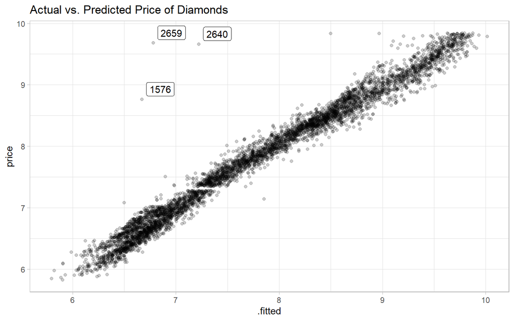

```r
ggplot(lm_predicted, aes(.fitted, price)) +
    geom_point(alpha = .2) +
    ggrepel::geom_label_repel(aes(label = rowid),
                              data = filter(lm_predicted, abs(.resid) > 2)) +
    labs(title = "Actual vs. Predicted Price of Diamonds")
```

# 5 Evaluating Model Performance: `yardstick::`

We already saw performance measures RMSE and R-squared in the output of `glance()` above. The **yardstick::** package is specifically designed for such measures for both numeric and categorical outcomes, and it plays well with grouped predictions (e.g., from cross-validation).

Let’s use **rsample**, **parsnip**, and **yardstick** for cross-validation to get a more accurate estimation of RMSE.

In the following pipeline, the model is `fit()` separately to the three *analysis data* sets, and then the fitted models are used to `predict()` on the three corresponding *assessment data* sets (i.e., 3-fold cross-validation).

Before that, `rsample::analysis()` and `rsample::assessment()` are used to extract the respective folds from `dia_vfold` which is a `rsplit` object made by `rsample::`.

Furthermore, the recipe `dia_rec` is `prep`ped (i.e., trained) using the analysis data of each fold, and this prepped recipe is then applied to the assessment data of each fold using `bake()`.

Preparing the recipe separately for each fold (rather than once for the whole training data set `dia_train`) guards against *data leakage*.

- [data leakage](https://machinelearningmastery.com/data-leakage-machine-learning/).

The code in the following chunk makes use of list-columns to store all information about the three folds in a single tibble `lm_fit2`, and a combination of `dplyr::mutate()` and `purrr::map()` is used to “loop” across the three rows of the tibble.

```r
# How does dia_vfold look?
dia_vfold
```

```
-->  #  3-fold cross-validation using stratification
-->  # A tibble: 3 x 2
-->    splits              id
-->    <list>              <chr>
-->  1 <split [3.6K/1.8K]> Fold1
-->  2 <split [3.6K/1.8K]> Fold2
-->  3 <split [3.6K/1.8K]> Fold3
```

```r
# Extract analysis/training and assessment/testing data
lm_fit2 <- mutate(dia_vfold,
                  df_ana = map(splits,  analysis),
                  df_ass = map(splits,  assessment))
```

```
-->      ---->  mutate: new variable 'df_ana' (list) with 3 unique values and 0% NA
-->      ---->          new variable 'df_ass' (list) with 3 unique values and 0% NA
```

```r
lm_fit2
```

```
-->  #  3-fold cross-validation using stratification
-->  # A tibble: 3 x 4
-->    splits              id    df_ana                df_ass
-->    <list>              <chr> <list>                <list>
-->  1 <split [3.6K/1.8K]> Fold1 <tibble [3,596 x 10]> <tibble [1,799 x 10]>
-->  2 <split [3.6K/1.8K]> Fold2 <tibble [3,596 x 10]> <tibble [1,799 x 10]>
-->  3 <split [3.6K/1.8K]> Fold3 <tibble [3,598 x 10]> <tibble [1,797 x 10]>
```

```r
lm_fit2 <-
    lm_fit2 %>%
    # prep, juice, bake
    mutate(
        recipe = map(df_ana, ~prep(dia_rec, training = .x)),
        df_ana = map(recipe,  juice),
        df_ass = map2(recipe,
                      df_ass, ~bake(.x, new_data = .y))) %>%
    # fit
    mutate(
        model_fit  = map(df_ana, ~fit(lm_model, price ~ ., data = .x))) %>%
    # predict
    mutate(
        model_pred = map2(model_fit, df_ass, ~predict(.x, new_data = .y)))
```

```
-->      ---->  mutate: changed 3 values (100%) of 'df_ana' (0 new NA)
-->      ---->          changed 3 values (100%) of 'df_ass' (0 new NA)
-->      ---->          new variable 'recipe' (list) with 3 unique values and 0% NA
-->      ---->  mutate: new variable 'model_fit' (list) with 3 unique values and 0% NA
-->      ---->  mutate: new variable 'model_pred' (list) with 3 unique values and 0% NA
```

```r
select(lm_fit2, id, recipe:model_pred)
```

```
-->      ---->  select: dropped 3 variables (splits, df_ana, df_ass)
```

```
-->  # A tibble: 3 x 4
-->    id    recipe   model_fit model_pred
-->    <chr> <list>   <list>    <list>
-->  1 Fold1 <recipe> <fit[+]>  <tibble [1,799 x 1]>
-->  2 Fold2 <recipe> <fit[+]>  <tibble [1,799 x 1]>
-->  3 Fold3 <recipe> <fit[+]>  <tibble [1,797 x 1]>
```

Note that the cross-validation code above is a bit lengthy—for didactic purposes. Wrapper functions (e.g., from the **tune::** package) would lead to more concise code: `fit_resamples()` could be used here (without tuning), or `tune_grid()` and `tune_bayes()` (see below).

Now, we can extract the actual prices `price` from the assessment data and compare them to the predicted prices `.pred`.

Then, the **yardstick::** package comes into play:

- The function `yardstick::metrics()` calculates three different metrics for numeric outcomes.
- Furthermore, it automatically recognizes that `lm_preds` is grouped by folds and thus calculates the metrics for each fold.

```r
lm_preds <-
    lm_fit2 %>%
    mutate(res = map2(df_ass, model_pred, ~data.frame(price = .x$price,
                                                      .pred = .y$.pred))) %>%
    select(id, res) %>%
    tidyr::unnest(res) %>%
    group_by(id)
```

```
-->      ---->  mutate: new variable 'res' (list) with 3 unique values and 0% NA
-->      ---->  select: dropped 6 variables (splits, df_ana, df_ass, recipe, model_fit, …)
-->      ---->  group_by: one grouping variable (id)
```

```r
lm_preds
```

```
-->  # A tibble: 5,395 x 3
-->  # Groups:   id [3]
-->     id    price .pred
-->     <chr> <dbl> <dbl>
-->   1 Fold1  5.84  5.83
-->   2 Fold1  6.00  6.25
-->   3 Fold1  6.00  6.05
-->   4 Fold1  6.32  6.56
-->   5 Fold1  6.32  6.31
-->   6 Fold1  7.92  7.73
-->   7 Fold1  7.93  7.58
-->   8 Fold1  7.93  7.80
-->   9 Fold1  7.93  7.88
-->  10 Fold1  7.94  7.91
-->  # ... with 5,385 more rows
```

```r
yardstick::metrics(lm_preds,
                   truth = price,
                   estimate = .pred)
```

```
-->  # A tibble: 9 x 4
-->    id    .metric .estimator .estimate
-->    <chr> <chr>   <chr>          <dbl>
-->  1 Fold1 rmse    standard       0.168
-->  2 Fold2 rmse    standard       0.147
-->  3 Fold3 rmse    standard       0.298
-->  4 Fold1 rsq     standard       0.973
-->  5 Fold2 rsq     standard       0.979
-->  6 Fold3 rsq     standard       0.918
-->  7 Fold1 mae     standard       0.116
-->  8 Fold2 mae     standard       0.115
-->  9 Fold3 mae     standard       0.110
```

Note that `metrics()` has default measures for numeric and categorical outcomes, and here RMSE, R-squared, and the mean absolute difference (MAE) are returned.

You could also use one metric directly like `rmse()` or define a custom set of metrics via `metric_set()`.

# 6 Tuning Model Parameters: `tune::` and `dials::`

Let’s get a little bit more involved and do some hyperparameter tuning. We turn to a different model, namely, a random forest model.

The **tune** package has functions for doing the actual tuning (e.g., via grid search), while all the parameters and their defaults (e.g., `mtry()`, `neighbors()`) are implemented in **dials**. Thus, the two packages can almost only be used in combination.

## 6.1 Preparing Model for Tuning: `parsnip`

First, I want to tune the `mtry` parameter of a random forest model. Thus, the model is defined using **parsnip** as above. However, rather than using a default value (i.e., `mtry = NULL`) or one specific value (i.e., `mtry = 3`), we use `tune()` as a placeholder and let cross-validation decide on the best value for `mtry` later on.

As the output indicates, the default minimum of `mtry` is 1 and the maximum depends on the data.

```r
rf_model <-
    rand_forest(mtry = tune()) %>%
    set_mode("regression") %>%
    set_engine("ranger")

parameters(rf_model)
```

```
-->  Collection of 1 parameters for tuning
-->
-->   identifier type    object
-->         mtry mtry nparam[?]
-->
-->  Model parameters needing finalization:
-->     # Randomly Selected Predictors ('mtry')
-->
-->  See `?dials::finalize` or `?dials::update.parameters` for more information.
```

```r
mtry()
```

```
-->  # Randomly Selected Predictors (quantitative)
-->  Range: [1, ?]
```

Thus, this model is not yet ready for fitting. You can either specify the maximum for `mtry` yourself using `update()`, or you can use `finalize()` to let the data decide on the maximum.

```r
rf_model %>%
    parameters() %>%
    update(mtry = mtry(c(1L, 5L)))
```

```
-->  Collection of 1 parameters for tuning
-->
-->   identifier type    object
-->         mtry mtry nparam[+]
```

```r
rf_model %>%
    parameters() %>%
    # Here, the maximum of mtry equals the number of predictors, i.e., 24.
    finalize(x = select(juice(prep(dia_rec)), -price)) %>%
    pull("object")
```

```
-->      ---->  select: dropped one variable (price)
```

```
-->  [[1]]
-->  # Randomly Selected Predictors (quantitative)
-->  Range: [1, 24]
```

## 6.2 Preparing Data for Tuning: `recipes`

The second thing I want to tune is the degree of the polynomial for the variable carat. As you saw in the plot above, polynomials up to a degree of four seemed well suited for the data. However, a simpler model might do equally well, and we want to use cross-validation to decide on the degree that works best.

Similar to tuning parameters in a model, certain aspects of a recipe can be tuned. Let’s define a second recipe and use `tune()` inside `step_poly()`.

```r
# Note that this recipe cannot be prepped (and baked), since "degree" is a
# tuning parameter
dia_rec2 <-
    recipe(price ~ ., data = dia_train) %>%
    step_log(all_outcomes()) %>%
    step_normalize(all_predictors(), -all_nominal()) %>%
    step_dummy(all_nominal()) %>%
    step_poly(carat, degree = tune())

dia_rec2 %>%
    parameters() %>%
    pull("object")
```

```
-->  [[1]]
-->  Polynomial Degree (quantitative)
-->  Range: [1, 3]
```

# 7 Combine Everything: `workflows::`

The **workflows** package is designed to bundle together different parts of a machine learning pipeline like a recipe or a model.

First, let’s create an initial workflow and add the recipe and the random forest model, both of which have a tuning parameter.

```r
rf_wflow <-
    workflow() %>%
    add_model(rf_model) %>%
    add_recipe(dia_rec2)
rf_wflow
```

```
-->  == Workflow ===========================================================================================================================================================================================================================================================================================…
-->  Preprocessor: Recipe
-->  Model: rand_forest()
-->
-->  -- Preprocessor ---------------------------------------------------------------------------------------------------------------------------------------------------------------------------------------------------------------------------------------------------------------------------------------…
-->  4 Recipe Steps
-->
-->  * step_log()
-->  * step_normalize()
-->  * step_dummy()
-->  * step_poly()
-->
-->  -- Model ----------------------------------------------------------------------------------------------------------------------------------------------------------------------------------------------------------------------------------------------------------------------------------------------…
-->  Random Forest Model Specification (regression)
-->
-->  Main Arguments:
-->    mtry = tune()
-->
-->  Computational engine: ranger
```

Second, we need to update the parameters in `rf_wflow`, because the maximum of `mtry` is not yet known and the maximum of `degree` should be four (while three is the default).

```r
rf_param <-
    rf_wflow %>%
    parameters() %>%
    update(mtry = mtry(range = c(3L, 5L)),
           degree = degree_int(range = c(2L, 4L)))
rf_param$object
```

```
-->  [[1]]
-->  # Randomly Selected Predictors (quantitative)
-->  Range: [3, 5]
-->
-->  [[2]]
-->  Polynomial Degree (quantitative)
-->  Range: [2, 4]
```

Third, we want to use cross-validation for tuning, that is, to select the best combination of the hyperparameters. Bayesian optimization (see [https://tidymodels.github.io/tune/](https://tidymodels.github.io/tune/articles/extras/svm_classification.html)) is recommended for complex tuning problems, and this can be done using `tune_bayes()`.

Herein, however, grid search will suffice. To this end, let’s create a grid of all necessary parameter combinations.

```r
rf_grid <- grid_regular(rf_param, levels = 3)
rf_grid
```

```
-->  # A tibble: 9 x 2
-->     mtry degree
-->    <int>  <int>
-->  1     3      2
-->  2     4      2
-->  3     5      2
-->  4     3      3
-->  5     4      3
-->  6     5      3
-->  7     3      4
-->  8     4      4
-->  9     5      4
```

Cross-validation and hyperparameter tuning can involve fitting many models. Herein, for example, we have to fit 3 x 9 models (folds x parameter combinations). To increase speed, we can fit the models in parallel. This is directly supported by the **tune** package (see [https://tidymodels.github.io/tune/](https://tidymodels.github.io/tune/articles/extras/optimizations.html#parallel-processing)).

```r
library("doFuture")
all_cores <- parallel::detectCores(logical = FALSE) - 1

registerDoFuture()
cl <- makeCluster(all_cores)
plan(future::cluster, workers = cl)
```

Then, we can finally start tuning.

```r
rf_search <- tune_grid(rf_wflow, grid = rf_grid, resamples = dia_vfold,
                       param_info = rf_param)
```

The results can be examined using `autoplot()` and `show_best()`:

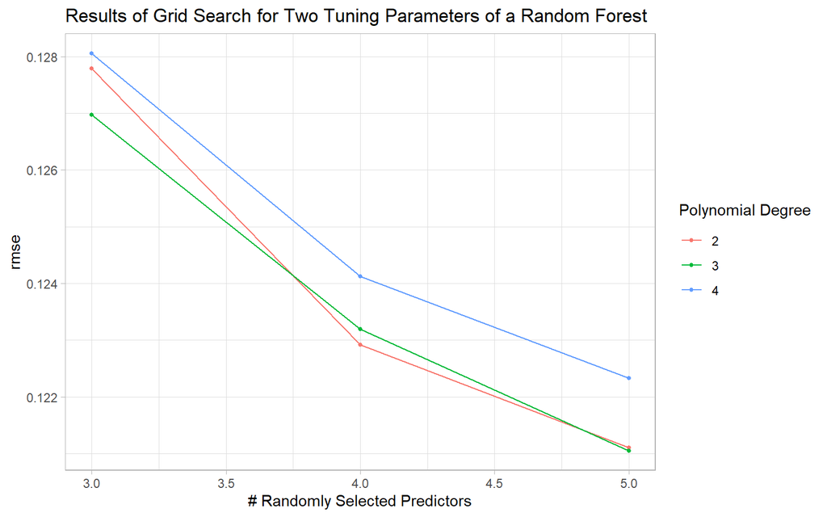

```r
autoplot(rf_search, metric = "rmse") +
    labs(title = "Results of Grid Search for Two Tuning Parameters of a Random Forest")
```

```r
show_best(rf_search, "rmse", n = 9)
```

```
-->  # A tibble: 9 x 8
-->     mtry degree .metric .estimator  mean     n std_err .config
-->    <int>  <int> <chr>   <chr>      <dbl> <int>   <dbl> <chr>
-->  1     5      3 rmse    standard   0.121     3 0.00461 Preprocessor2_Model3
-->  2     5      2 rmse    standard   0.121     3 0.00464 Preprocessor1_Model3
-->  3     5      4 rmse    standard   0.122     3 0.00466 Preprocessor3_Model3
-->  4     4      2 rmse    standard   0.123     3 0.00462 Preprocessor1_Model2
-->  5     4      3 rmse    standard   0.123     3 0.00486 Preprocessor2_Model2
-->  6     4      4 rmse    standard   0.124     3 0.00470 Preprocessor3_Model2
-->  7     3      3 rmse    standard   0.127     3 0.00463 Preprocessor2_Model1
-->  8     3      2 rmse    standard   0.128     3 0.00515 Preprocessor1_Model1
-->  9     3      4 rmse    standard   0.128     3 0.00469 Preprocessor3_Model1
```

```r
select_best(rf_search, metric = "rmse")
```

```
-->  # A tibble: 1 x 3
-->     mtry degree .config
-->    <int>  <int> <chr>
-->  1     5      3 Preprocessor2_Model3
```

```r
select_by_one_std_err(rf_search, mtry, degree, metric = "rmse")
```

```
-->  # A tibble: 1 x 10
-->     mtry degree .metric .estimator  mean     n std_err .config              .best .bound
-->    <int>  <int> <chr>   <chr>      <dbl> <int>   <dbl> <chr>                <dbl>  <dbl>
-->  1     4      2 rmse    standard   0.123     3 0.00462 Preprocessor1_Model2 0.121  0.126
```

With a cross-validation RMSE of ca. 0.12, the random forest model seems to outperform the linear regression from above. Furthermore, 0.12 is (hopefully) a realistic estimate of the out-of-sample error.

### 7.0.1 Selecting the Best Model to Make the Final Predictions

We saw above that a quadratic trend was enough to get a good model. Furthermore, cross-validation revealed that `mtry = 4` seems to perform well.

To use this combination of hyperparameters, we `fit()` the corresponding model (or workflow, more precisely) on the whole training data set `dia_train`.

```r
rf_param_final <- select_by_one_std_err(rf_search, mtry, degree,
                                        metric = "rmse")

rf_wflow_final <- finalize_workflow(rf_wflow, rf_param_final)

rf_wflow_final_fit <- fit(rf_wflow_final, data = dia_train)
```

Now, we want to use this to `predict()` on data never seen before, namely, `dia_test`. Unfortunately, `predict(rf_wflow_final_fit, new_data = dia_test)` does not work in the present case, because the outcome is modified in the recipe via `step_log()`.

- Using (a workflow with) a recipe, which modifies the outcome, for prediction would require skipping the respective recipe step at `bake()` time via `step_log(skip = TRUE)`. While this is a good idea for predicting on the test data, it is a bad idea for predicting on the assessment data during cross-validation (see also https://github.com/tidymodels/workflows/issues/31).

Thus, we need a little workaround: The prepped recipe is extracted from the workflow, and this can then be used to `bake()` the testing data. This baked data set together with the extracted model can then be used for the final predictions.

```r
dia_rec3     <- pull_workflow_prepped_recipe(rf_wflow_final_fit)
rf_final_fit <- pull_workflow_fit(rf_wflow_final_fit)

dia_test$.pred <- predict(rf_final_fit,
                          new_data = bake(dia_rec3, dia_test))$.pred
dia_test$logprice <- log(dia_test$price)

metrics(dia_test, truth = logprice, estimate = .pred)
```

```
-->  # A tibble: 3 x 3
-->    .metric .estimator .estimate
-->    <chr>   <chr>          <dbl>
-->  1 rmse    standard      0.113
-->  2 rsq     standard      0.988
-->  3 mae     standard      0.0847
```

As you can see, we get an RMSE of 0.11 on the testing data, which is even slightly better compared to the cross-validation RMSE.

## 7.1 Summary

The tidymodels ecosystem bundles together a set of packages that work hand in hand to solve machine-learning problems from start to end. Together with the data-wrangling facilities in the **tidyverse** and the plotting tools from **ggplot2**, this makes for a rich toolbox for every data scientist working with R.

## 7.2 Further Resources

- For further information about each of the tidymodels packages, I recommend the vignettes/articles on the respective package homepage (e.g., https://tidymodels.github.io/recipes/ or https://tidymodels.github.io/tune/).
- Max Kuhn, one of the developer of tidymodels packages, was interviewed on the [R podcast](https://r-podcast.org/episode/028-max-kuhn/) and on the [DataFramed](https://www.datacamp.com/community/podcast/data-science-pharmaceuticals) podcast.
- [R for Data Science](https://r4ds.had.co.nz/) by Hadley Wickham and Garrett Grolemund covers all the basics of data import, transformation, visualization, and modeling using tidyverse and tidymodels packages.
- Variable importance (plots) are provided by the package [vip](https://koalaverse.github.io/vip/), which works well in combination with tidymodels packages.
- Recipe steps for dealing with unbalanced data are provided by the [themis](https://cran.r-project.org/web/packages/themis/index.html) package.
- There are a few more tidymodels packages that I did not cover herein, like **infer** or **tidytext**. Read more about these at https://tidymodels.github.io/tidymodels/.

### Source

This is a modified version of the posting in [Tutorial on tidymodels for Machine Learning](https://hansjoerg.me/2020/02/09/tidymodels-for-machine-learning/)